# ISLR Chapter 5

Abhirup Sen

10/05/2021

```r
library(dplyr)
library(ISLR)

attach(Default)

glimpse(Default)
```

```
## Rows: 10,000
## Columns: 4
## $ default <fct> No, No, No, No, No, No, No, No, No, No, No, No, No, No, No, No~
## $ student <fct> No, Yes, No, No, No, Yes, No, Yes, No, No, Yes, Yes, No, No, N~
## $ balance <dbl> 729.5265, 817.1804, 1073.5492, 529.2506, 785.6559, 919.5885, 8~
## $ income  <dbl> 44361.625, 12106.135, 31767.139, 35704.494, 38463.496, 7491.55~
```

**Predicting default with income & balance - Logistic Regression** Q: Fit a logistic regression model that uses income and balance to predict default.

```r
log_def <- glm(default ~ income + balance, data = Default, family = "binomial")

summary(log_def)
```

```
##
## Call:
## glm(formula = default ~ income + balance, family = "binomial",
##     data = Default)
##
## Deviance Residuals:
##     Min       1Q   Median       3Q      Max
## -2.4725  -0.1444  -0.0574  -0.0211   3.7245
##
## Coefficients:
##               Estimate Std. Error z value Pr(>|z|)
## (Intercept) -1.154e+01  4.348e-01 -26.545  < 2e-16 ***
## income       2.081e-05  4.985e-06   4.174 2.99e-05 ***
## balance      5.647e-03  2.274e-04  24.836  < 2e-16 ***
## ---
## Signif. codes:  0 '***' 0.001 '**' 0.01 '*' 0.05 '.' 0.1 ' ' 1
##
## (Dispersion parameter for binomial family taken to be 1)
##
##     Null deviance: 2920.6  on 9999  degrees of freedom
## Residual deviance: 1579.0  on 9997  degrees of freedom
## AIC: 1585
##
## Number of Fisher Scoring iterations: 8
```

**(b) Validation Approach - Estimating test Error** Using the validation set approach, estimate the test error of this model. In order to do this, you must perform the following steps:

1. train/test Split Q: Split the sample set into a training set and a validation set.

A:

70/30 split for train/test respectively:

```r
library(caret)
index <- createDataPartition(y = Default$default, p = 0.7, list = F)

train <- Default[index, ]
test <- Default[-index, ]

nrow(train) / nrow(Default)
```

```
## [1] 0.7001
```

**(ii) train - Fitting a Logistic Regression Model** Q: Fit a multiple logistic regression model using only the training observations.

```r
log_def_2 <- glm(default ~ income + balance, data = train, family = "binomial")

summary(log_def_2)
```

```
##
## Call:
## glm(formula = default ~ income + balance, family = "binomial",
##     data = train)
##
## Deviance Residuals:
##     Min       1Q   Median       3Q      Max
## -2.4681  -0.1470  -0.0578  -0.0211   3.7293
##
## Coefficients:
##               Estimate Std. Error z value Pr(>|z|)
## (Intercept) -1.143e+01  5.219e-01 -21.910  < 2e-16 ***
## income       1.676e-05  5.938e-06   2.822  0.00477 **
## balance      5.683e-03  2.747e-04  20.688  < 2e-16 ***
## ---
## Signif. codes:  0 '***' 0.001 '**' 0.01 '*' 0.05 '.' 0.1 ' ' 1
##
## (Dispersion parameter for binomial family taken to be 1)
##
##     Null deviance: 2050.6  on 7000  degrees of freedom
## Residual deviance: 1116.5  on 6998  degrees of freedom
## AIC: 1122.5
##
## Number of Fisher Scoring iterations: 8
```

**(iii) test Predictions** Q: Obtain a prediction of default status for each individual in the validation set by computing the posterior probability of default for that individual, and classifying the individual to the default category if the posterior probability is greater than 0.5.

```r
test_pred <- factor(ifelse(predict(log_def_2, newdata = test, type = "response") > 0.5, "Yes", "No"))
test_pred[1:10]
```

```
##  2  3  7  9 11 12 13 14 15 17
## No No No No No No No No No No
## Levels: No Yes
```

**(iv) test Error** Q: Compute the validation set error, which is the fraction of the observations in the validation set that are misclassified.

```r
round(mean(test$default != test_pred), 5)
```

```
## [1] 0.02501
```

**(c) Repeating the train/test Splits** Q: Repeat the process in (b) three times, using three different splits of the observations into a training set and a validation set. Comment on the results obtained.

```r
log_def_errors <- c()


log_def_errors[1] <- mean(test$default != test_pred)

set.seed(42, sample.kind = "Rounding")
for (i in 2:4) {
  index <- createDataPartition(y = Default$default, p = 0.7, list = F)
  train <- Default[index, ]
  test <- Default[-index, ]

  log_def <- glm(default ~ income + balance, data = train, family = "binomial")
  test_pred <- factor(ifelse(predict(log_def, newdata = test, type = "response") > 0.5, "Yes", "No"))

  log_def_errors[i] <- mean(test$default != test_pred)
}


round(log_def_errors, 5)
```

```
## [1] 0.02501 0.02534 0.02601 0.02534
```

**(d) Does Adding student Improve test Performance?** Q: Now consider a logistic regression model that predicts the probability of default using income, balance, and a dummy variable for student. Estimate the test error for this model using the validation set approach. Comment on whether or not including a dummy variable for student leads to a reduction in the test error rate.

```r
index <- createDataPartition(y = Default$default, p = 0.7, list = F)
train <- Default[index, ]
test <- Default[-index, ]

log_def <- glm(default ~ ., data = train, family = "binomial")
summary(log_def)
```

```
##
## Call:
## glm(formula = default ~ ., family = "binomial", data = train)
##
## Deviance Residuals:
##     Min       1Q   Median       3Q      Max
## -2.1511  -0.1387  -0.0527  -0.0185   3.7089
##
## Coefficients:
##               Estimate Std. Error z value Pr(>|z|)
## (Intercept) -1.100e+01  6.032e-01 -18.237  < 2e-16 ***
## studentYes  -7.307e-01  2.823e-01  -2.588  0.00964 **
## balance      5.875e-03  2.844e-04  20.654  < 2e-16 ***
## income       6.377e-07  9.844e-06   0.065  0.94835
## ---
## Signif. codes:  0 '***' 0.001 '**' 0.01 '*' 0.05 '.' 0.1 ' ' 1
##
## (Dispersion parameter for binomial family taken to be 1)
##
##     Null deviance: 2050.6  on 7000  degrees of freedom
## Residual deviance: 1084.4  on 6997  degrees of freedom
## AIC: 1092.4
##
## Number of Fisher Scoring iterations: 8
```

```r
test_pred <- factor(ifelse(predict(log_def, newdata = test, type = "response") > 0.5, "Yes", "No"))
```

```r
round(mean(test$default != test_pred), 5)
```

```
## [1] 0.02868
```

It appears that the test error for this model is larger than the test error for the smaller model (larger than all 4 of them, in fact), so including a dummy variable for student does not reduce the test error rate.

**(a) Logistic Regression - Coefficient SE Estimates** Q: Using the summary() and glm() functions, determine the estimated standard errors for the coefficients associated with income and balance in a multiple logistic regression model that uses both predictors.

```r
log_def <- glm(default ~ income + balance, data = Default, family = "binomial")

summary(log_def)$coefficients[, 2]
```

```
##  (Intercept)       income      balance
## 4.347564e-01 4.985167e-06 2.273731e-04
```

**(b) Creating boot.fn() - Estimating Logistic Coefficients** Q: Write a function, boot.fn(), that takes as input the Default data set as well as an index of the observations, and that outputs the coefficient estimates for income and balance in the multiple logistic regression model.

```r
boot.fn <- function(data, index = 1:nrow(data)) {
  coef(glm(default ~ income + balance, data = data, subset = index, family = "binomial"))[-1]
}

boot.fn(Default)
```

```
##       income      balance
## 2.080898e-05 5.647103e-03
```

**(c) boot.fn() & boot::boot() - Bootstrap Estimate of Coefficient SE’s** Q: Use the boot() function together with your boot.fn() function to estimate the standard errors of the logistic regression coefficients for income and balance.

```r
library(boot)
set.seed(101, sample.kind = "Rounding")
(boot_results <- boot(data = Default, statistic = boot.fn, R = 1000))
```

```
##
## ORDINARY NONPARAMETRIC BOOTSTRAP
##
##
## Call:
## boot(data = Default, statistic = boot.fn, R = 1000)
##
##
## Bootstrap Statistics :
##         original       bias     std. error
## t1* 2.080898e-05 9.797648e-08 4.710812e-06
## t2* 5.647103e-03 1.345215e-05 2.293757e-04
```

**(d) Logistic SE’s & Bootstrap SE’s - Differences** Q: Comment on the estimated standard errors obtained using the glm() function and using your bootstrap function.

```r
sapply(data.frame(income = boot_results$t[ ,1], balance = boot_results$t[ ,2]), sd)
```

```
##       income      balance
## 4.710812e-06 2.293757e-04
```

```r
summary(log_def)$coefficients[2:3, 2]
```

```
##       income      balance
## 4.985167e-06 2.273731e-04
```

```r
attach(Weekly)
glimpse(Weekly)
```

```
## Rows: 1,089
## Columns: 9
## $ Year      <dbl> 1990, 1990, 1990, 1990, 1990, 1990, 1990, 1990, 1990, 1990, ~
## $ Lag1      <dbl> 0.816, -0.270, -2.576, 3.514, 0.712, 1.178, -1.372, 0.807, 0~
## $ Lag2      <dbl> 1.572, 0.816, -0.270, -2.576, 3.514, 0.712, 1.178, -1.372, 0~
## $ Lag3      <dbl> -3.936, 1.572, 0.816, -0.270, -2.576, 3.514, 0.712, 1.178, -~
## $ Lag4      <dbl> -0.229, -3.936, 1.572, 0.816, -0.270, -2.576, 3.514, 0.712, ~
## $ Lag5      <dbl> -3.484, -0.229, -3.936, 1.572, 0.816, -0.270, -2.576, 3.514,~
## $ Volume    <dbl> 0.1549760, 0.1485740, 0.1598375, 0.1616300, 0.1537280, 0.154~
## $ Today     <dbl> -0.270, -2.576, 3.514, 0.712, 1.178, -1.372, 0.807, 0.041, 1~
## $ Direction <fct> Down, Down, Up, Up, Up, Down, Up, Up, Up, Down, Down, Up, Up~
```

**a. Predicting Direction with Lag1 & Lag2 - Logistic Regression** Q: Fit a logistic regression model that predicts Direction using Lag1 and Lag2.

```r
log_dir <- glm(Direction ~ Lag1 + Lag2, data = Weekly, family = "binomial")
summary(log_dir)
```

```
##
## Call:
## glm(formula = Direction ~ Lag1 + Lag2, family = "binomial", data = Weekly)
##
## Deviance Residuals:
##    Min      1Q  Median      3Q     Max
## -1.623  -1.261   1.001   1.083   1.506
##
## Coefficients:
##             Estimate Std. Error z value Pr(>|z|)
## (Intercept)  0.22122    0.06147   3.599 0.000319 ***
## Lag1        -0.03872    0.02622  -1.477 0.139672
## Lag2         0.06025    0.02655   2.270 0.023232 *
## ---
## Signif. codes:  0 '***' 0.001 '**' 0.01 '*' 0.05 '.' 0.1 ' ' 1
##
## (Dispersion parameter for binomial family taken to be 1)
##
##     Null deviance: 1496.2  on 1088  degrees of freedom
## Residual deviance: 1488.2  on 1086  degrees of freedom
## AIC: 1494.2
##
## Number of Fisher Scoring iterations: 4
```

**(b) Omitting One Observation from Training** Q: Fit a logistic regression model that predicts Direction using Lag1 and Lag2 using all but the first observation.

```r
log_dir_2 <- glm(Direction ~ Lag1 + Lag2, data = Weekly[-1, ], family = "binomial")
summary(log_dir_2)
```

```
##
## Call:
## glm(formula = Direction ~ Lag1 + Lag2, family = "binomial", data = Weekly[-1,
##     ])
##
## Deviance Residuals:
##     Min       1Q   Median       3Q      Max
## -1.6258  -1.2617   0.9999   1.0819   1.5071
##
## Coefficients:
##             Estimate Std. Error z value Pr(>|z|)
## (Intercept)  0.22324    0.06150   3.630 0.000283 ***
## Lag1        -0.03843    0.02622  -1.466 0.142683
## Lag2         0.06085    0.02656   2.291 0.021971 *
## ---
## Signif. codes:  0 '***' 0.001 '**' 0.01 '*' 0.05 '.' 0.1 ' ' 1
##
## (Dispersion parameter for binomial family taken to be 1)
##
##     Null deviance: 1494.6  on 1087  degrees of freedom
## Residual deviance: 1486.5  on 1085  degrees of freedom
## AIC: 1492.5
##
## Number of Fisher Scoring iterations: 4
```

**(c) Predicting the Omitted Observation** Q: Use the model from (b) to predict the direction of the first observation. You can do this by predicting that the first observation will go up if P(Direction=Up|Lag1,Lag2)>0.5. Was this observation correctly classified?

```r
ifelse(predict(log_dir_2, newdata = Weekly[1, ], type = "response") > 0.5, "Up", "Down")
```

```
##    1
## "Up"
```

```r
as.character(Weekly[1, "Direction"])
```

```
## [1] "Down"
```

**(d) Writing a LOOCV Loop** Q: Write a for loop from i = 1 to i = n, where n is the number of observations in the data set, that performs each of the following steps:

1. Fit a logistic regression model using all but the ith observation to predict Direction using Lag1 and Lag2.
2. Compute the posterior probability of the market moving up for the ith observation.
3. Use the posterior probability for the ith observation in order to predict whether or not the market moves up.
4. Determine whether or not an error was made in predicting the direction for the ith observation. If an error was made, then indicate this as a 1, and otherwise indicate it as a 0.

```r
error <- c()

for (i in 1:nrow(Weekly)) {
  log_dir <- glm(Direction ~ Lag1 + Lag2, data = Weekly[-i, ], family = "binomial") # i.
  prediction <- ifelse(predict(log_dir, newdata = Weekly[i, ], type = "response") > 0.5, "Up", "Down") # ii. & iii.
  error[i] <- as.numeric(prediction != Weekly[i, "Direction"]) # iv.
}

error[1:10]
```

```
##  [1] 1 1 0 1 0 1 0 0 0 1
```

**(e) The LOOCV Estimate for the Test Error** Q: Take the average of the n numbers obtained in (d) iv. in order to obtain the LOOCV estimate for the test error. Comment on the results.

```r
mean(error)
```

```
## [1] 0.4499541
```

The LOOCV estimate for the test error is ≈ 0.45. Looking at the split of Direction between Up and Down:

```r
prop.table(table(Weekly$Direction))
```

```
##
##      Down        Up
## 0.4444444 0.5555556
```

We can see that a classifier that predicted that the Direction of the S&P 500 will go Up every week between 1990 and 2010 would have achieved an error of 0.444, so if the LOOCV estimate is anything to go by, our classifier isn’t much good.

##Problem 8

**(a) Simulated Relationship** Q: Generate a simulated data set as follows:

```r
set.seed(1)
x = rnorm(100)
y = x - 2*x^2 + rnorm (100)
```

**(b) Plot: Y vs X** Q: Create a scatterplot of X against Y . Comment on what you find.

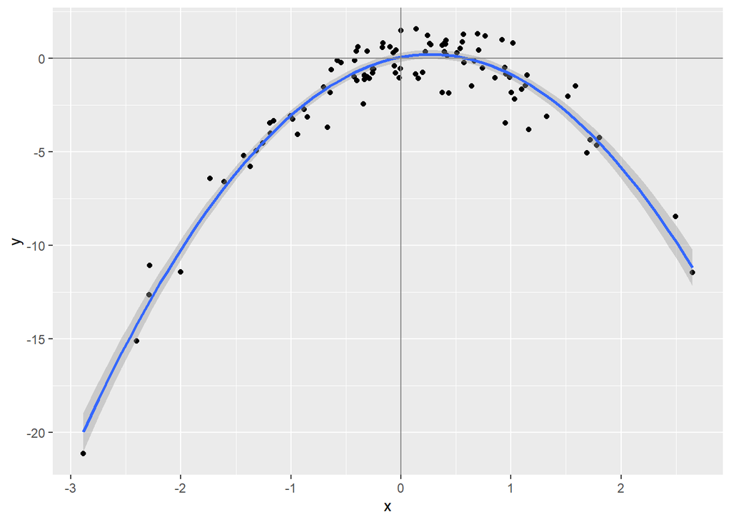

```r
x <- rnorm(100)
y <- x - 2*x^2 + rnorm(100)

ggplot(mapping = aes(x = x, y = y)) +
  geom_point() +
  geom_smooth(method = "lm", formula = "y ~ x + I(x^2)") +
  geom_hline(yintercept = 0, col = "grey55") +
  geom_vline(xintercept = 0, col = "grey55")
```

**(c) LOOCV - Model Implementations & Comparisons** Q: Set a random seed, and then compute the LOOCV errors that result from fitting the following four models using least squares:

```r
data <- data.frame(x = x, y = y)


start_time <- Sys.time()

for (j in 1:10) {
  glm_1 <- glm(y ~ x + I(x^2), data = data)
  cv_glm_1 <- cv.glm(data, glm_1)
  LOOCV_MSE <- cv_glm_1$delta[1]
}

end_time <- Sys.time()

LOOCV_MSE
```

```
## [1] 1.033232
```

```r
round(end_time - start_time, 3)
```

```
## Time difference of 9.154 secs
```

**The LOOCV estimate using my loop method (adapted for a regression problem):**

```r
start_time <- Sys.time()

for (j in 1:10) {
  error <- c()
  for (i in 1:nrow(data)) {
    model <- glm(y ~ x + I(x^2), data = data[-i,])
    prediction <- predict(model, newdata = data[i,])
    error[i] <- (prediction - data[i, "y"]) ^ 2
    if (i == nrow(data)) {
      LOOCV_MSE <- mean(error)
    }
  }
}

end_time <- Sys.time()

LOOCV_MSE
```

```
## [1] 1.033232
```

```r
round(end_time - start_time, 3)
```

```
## Time difference of 6.639 secs
```

**The LOOCV estimate using the ‘linear algebra black magic’ shortcut formula:**

```r
start_time <- Sys.time()

for (j in 1:10) {
  glm_2 <- glm(y ~ x + I(x^2), data = data)
  LOOCV_MSE <- mean(((data$y - predict(glm_2)) / (1 - glm.diag(glm_2)$h)) ^ 2)
}

end_time <- Sys.time()

LOOCV_MSE
```

```
## [1] 1.033232
```

```r
round(end_time - start_time, 3)
```

```
## Time difference of 0.155 secs
```

```r
LOOCV <- function(data, formula) {
  model <- glm(formula(formula), data = data)
  mean(((data$y - predict(model))/(1 - boot::glm.diag(model)$h))^2)
}
```

```r
LOOCV(data, "y ~ x") %>% round(3)
```

```
## [1] 12.723
```

```r
LOOCV(data, "y ~ x + I(x^2)") %>% round(3)
```

```
## [1] 1.033
```

```r
LOOCV(data, "y ~ x + I(x^2) + I(x^3)") %>% round(3)
```

```
## [1] 1.049
```

```r
LOOCV(data, "y ~ x + I(x^2) + I(x^3) + I(x^4)") %>% round(3)
```

```
## [1] 1.094
```

**(d) LOOCV and Random Seeds** Q: Repeat (c) using another random seed, and report your results. Are your results the same as what you got in (c)? Why?

```r
LOOCV_first_order <- LOOCV(data, "y ~ x")
round(LOOCV_first_order, 3)
```

```
## [1] 12.723
```

```r
LOOCV_second_order <- LOOCV(data, "y ~ x + I(x^2)")
round(LOOCV_second_order, 3)
```

```
## [1] 1.033
```

```r
LOOCV_third_order <- LOOCV(data, "y ~ x + I(x^2) + I(x^3)")
round(LOOCV_third_order, 3)
```

```
## [1] 1.049
```

```r
LOOCV_fourth_order <- LOOCV(data, "y ~ x + I(x^2) + I(x^3) + I(x^4)")
round(LOOCV_fourth_order, 3)
```

```
## [1] 1.094
```

**(e) LOOCV Error Comparison** Q: Which of the models in (c) had the smallest LOOCV error? Is this what you expected? Explain your answer.

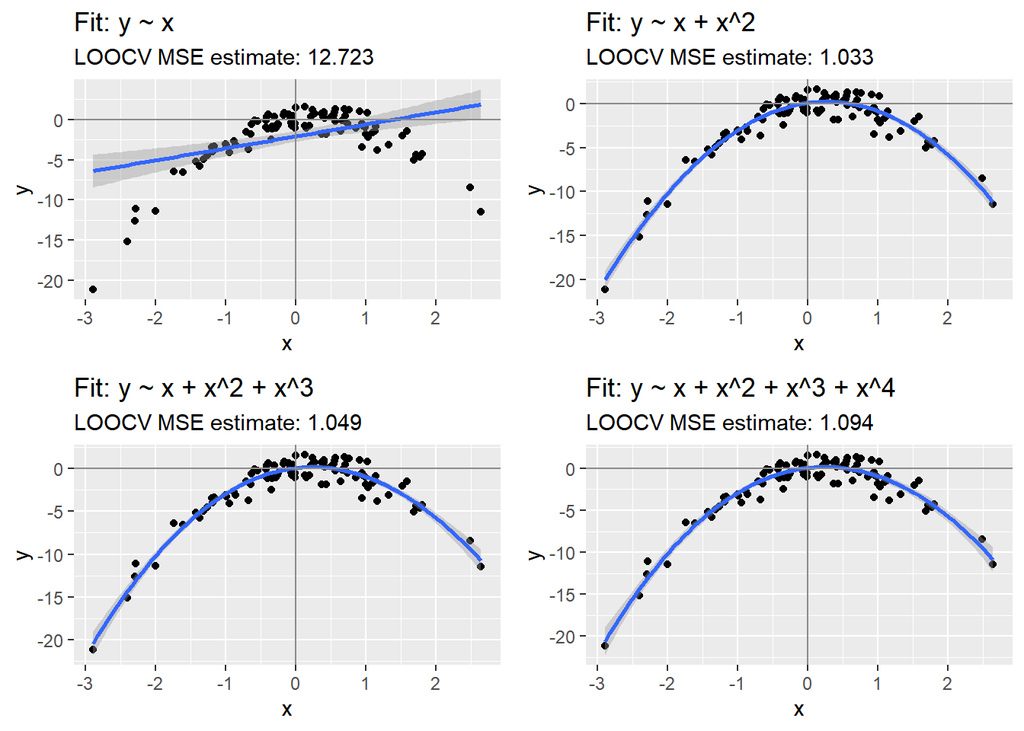

```r
g1 <- ggplot(mapping = aes(x = x, y = y)) +
  geom_point() +
  geom_smooth(method = "lm", formula = "y ~ x") +
  geom_hline(yintercept = 0, col = "grey55") +
  geom_vline(xintercept = 0, col = "grey55") +
  labs(title = "Fit: y ~ x",
       subtitle = paste0("LOOCV MSE estimate: ", round(LOOCV_first_order, 3)))

g2 <- ggplot(mapping = aes(x = x, y = y)) +
  geom_point() +
  geom_smooth(method = "lm", formula = "y ~ x + I(x^2)") +
  geom_hline(yintercept = 0, col = "grey55") +
  geom_vline(xintercept = 0, col = "grey55") +
  labs(title = "Fit: y ~ x + x^2",
       subtitle = paste0("LOOCV MSE estimate: ", round(LOOCV_second_order, 3)))

g3 <- ggplot(mapping = aes(x = x, y = y)) +
  geom_point() +
  geom_smooth(method = "lm", formula = "y ~ x + I(x^2) + I(x^3)") +
  geom_hline(yintercept = 0, col = "grey55") +
  geom_vline(xintercept = 0, col = "grey55") +
  labs(title = "Fit: y ~ x + x^2 + x^3",
       subtitle = paste0("LOOCV MSE estimate: ", round(LOOCV_third_order, 3)))

g4 <- ggplot(mapping = aes(x = x, y = y)) +
  geom_point() +
  geom_smooth(method = "lm", formula = "y ~ x + I(x^2) + I(x^3) + I(x^4)") +
  geom_hline(yintercept = 0, col = "grey55") +
  geom_vline(xintercept = 0, col = "grey55") +
  labs(title = "Fit: y ~ x + x^2 + x^3 + x^4",
       subtitle = paste0("LOOCV MSE estimate: ", round(LOOCV_fourth_order, 3)))

gridExtra::grid.arrange(g1, g2, g3, g4, nrow = 2, ncol = 2)
```

**(f) Coefficient Significance & Cross-Validation MSE** Q: Comment on the statistical significance of the coefficient estimates that results from fitting each of the models in (c) using least squares. Do these results agree with the conclusions drawn based on the cross-validation results?

```r
summary(glm(y ~ x, data = data))$coefficients %>% round(6)
```

```
##              Estimate Std. Error   t value Pr(>|t|)
## (Intercept) -2.082765   0.340561 -6.115684  0.0e+00
## x            1.491666   0.330800  4.509272  1.8e-05
```

```r
summary(glm(y ~ x + I(x^2), data = data))$coefficients %>% round(6)
```

```
##              Estimate Std. Error    t value Pr(>|t|)
## (Intercept)  0.072183   0.119714   0.602964  0.54794
## x            1.101926   0.097436  11.309233  0.00000
## I(x^2)      -2.022272   0.062407 -32.404616  0.00000
```

```r
summary(glm(y ~ x + I(x^2) + I(x^3), data = data))$coefficients %>% round(6)
```

```
##              Estimate Std. Error    t value Pr(>|t|)
## (Intercept)  0.071265   0.119773   0.595003 0.553241
## x            0.971951   0.167461   5.804030 0.000000
## I(x^2)      -2.011628   0.063423 -31.717419 0.000000
## I(x^3)       0.037687   0.039481   0.954546 0.342205
```

```r
summary(glm(y ~ x + I(x^2) + I(x^3) + I(x^4), data = data))$coefficients %>% round(6)
```

```
##              Estimate Std. Error    t value Pr(>|t|)
## (Intercept)  0.049655   0.140361   0.353766 0.724298
## x            0.974797   0.168530   5.784116 0.000000
## I(x^2)      -1.963298   0.173674 -11.304486 0.000000
## I(x^3)       0.035762   0.040188   0.889866 0.375786
## I(x^4)      -0.008106   0.027097  -0.299145 0.765483
```

## Problem 9

```r
library(MASS)
glimpse(Boston)
```

```
## Rows: 506
## Columns: 14
## $ crim    <dbl> 0.00632, 0.02731, 0.02729, 0.03237, 0.06905, 0.02985, 0.08829,~
## $ zn      <dbl> 18.0, 0.0, 0.0, 0.0, 0.0, 0.0, 12.5, 12.5, 12.5, 12.5, 12.5, 1~
## $ indus   <dbl> 2.31, 7.07, 7.07, 2.18, 2.18, 2.18, 7.87, 7.87, 7.87, 7.87, 7.~
## $ chas    <int> 0, 0, 0, 0, 0, 0, 0, 0, 0, 0, 0, 0, 0, 0, 0, 0, 0, 0, 0, 0, 0,~
## $ nox     <dbl> 0.538, 0.469, 0.469, 0.458, 0.458, 0.458, 0.524, 0.524, 0.524,~
## $ rm      <dbl> 6.575, 6.421, 7.185, 6.998, 7.147, 6.430, 6.012, 6.172, 5.631,~
## $ age     <dbl> 65.2, 78.9, 61.1, 45.8, 54.2, 58.7, 66.6, 96.1, 100.0, 85.9, 9~
## $ dis     <dbl> 4.0900, 4.9671, 4.9671, 6.0622, 6.0622, 6.0622, 5.5605, 5.9505~
## $ rad     <int> 1, 2, 2, 3, 3, 3, 5, 5, 5, 5, 5, 5, 5, 4, 4, 4, 4, 4, 4, 4, 4,~
## $ tax     <dbl> 296, 242, 242, 222, 222, 222, 311, 311, 311, 311, 311, 311, 31~
## $ ptratio <dbl> 15.3, 17.8, 17.8, 18.7, 18.7, 18.7, 15.2, 15.2, 15.2, 15.2, 15~
## $ black   <dbl> 396.90, 396.90, 392.83, 394.63, 396.90, 394.12, 395.60, 396.90~
## $ lstat   <dbl> 4.98, 9.14, 4.03, 2.94, 5.33, 5.21, 12.43, 19.15, 29.93, 17.10~
## $ medv    <dbl> 24.0, 21.6, 34.7, 33.4, 36.2, 28.7, 22.9, 27.1, 16.5, 18.9, 15~
```

**(a) Estimate the medv Population Mean - μ^** Q: Based on this data set, provide an estimate for the population mean of medv. Call this estimate μ^.

```r
mean(Boston$medv)
```

```
## [1] 22.53281
```

**(b) Estimate SE(μ^) - Using Theory** Q: Provide an estimate of the standard error of μ^. Interpret this result.

Hint: We can compute the standard error of the sample mean by dividing the sample standard deviation by the square root of the number of observations

```r
sd(Boston$medv) / sqrt(length(Boston$medv))
```

```
## [1] 0.4088611
```

**(c) Estimate SE(μ^) - Using the Bootstrap** Q: Now estimate the standard error of μ^ using the bootstrap. How does this compare to your answer from (b)?

```r
boot.fn <- function(vector, index) {
  mean(vector[index])
}


(boot_results <- boot(data = Boston$medv, statistic = boot.fn, R = 1000))
```

```
##
## ORDINARY NONPARAMETRIC BOOTSTRAP
##
##
## Call:
## boot(data = Boston$medv, statistic = boot.fn, R = 1000)
##
##
## Bootstrap Statistics :
##     original      bias    std. error
## t1* 22.53281 0.009576285   0.4135401
```

**(d) 95% Confidence Interval for the Mean - Using the Bootstrap** Q: Based on your bootstrap estimate from (c), provide a 95% confidence interval for the mean of medv. Compare it to the results obtained using t.test(Boston$medv).

```r
boot_results_SE <- sd(boot_results$t)
round(c(mean(Boston$medv) - 2*boot_results_SE, mean(Boston$medv) + 2*boot_results_SE), 4)
```

```
## [1] 21.7057 23.3599
```

```r
t.test(Boston$medv)
```

```
##
##  One Sample t-test
##
## data:  Boston$medv
## t = 55.111, df = 505, p-value < 2.2e-16
## alternative hypothesis: true mean is not equal to 0
## 95 percent confidence interval:
##  21.72953 23.33608
## sample estimates:
## mean of x
##  22.53281
```

**(e) Estimate the medv Population Median - μ^med** Q: Based on this data set, provide an estimate, μ^med, for the median value of medv in the population.

```r
median(Boston$medv)
```

```
## [1] 21.2
```

**(f) Estimate SE(μ^med) - Using the Bootstrap** Q: We now would like to estimate the standard error of μ^med. Unfortunately, there is no simple formula for computing the standard error of the median. Instead, estimate the standard error of the median using the bootstrap. Comment on your findings.

```r
boot.fn <- function(vector, index) {
  median(vector[index])
}

(boot_results <- boot(data = Boston$medv, statistic = boot.fn, R = 1000))
```

```
##
## ORDINARY NONPARAMETRIC BOOTSTRAP
##
##
## Call:
## boot(data = Boston$medv, statistic = boot.fn, R = 1000)
##
##
## Bootstrap Statistics :
##     original  bias    std. error
## t1*     21.2 -0.0129   0.3858594
```

**(g) Estimate the medv Population 10th Percentile - μ^0.1** Q: Based on this data set, provide an estimate for the tenth percentile of medv in Boston suburbs. Call this quantity μ^0.1. (You can use the quantile() function.)

```r
quantile(Boston$medv, 0.1)
```

```
##   10%
## 12.75
```

**(h) Estimate SE(μ^0.1) - Using the Bootstrap** Q: Use the bootstrap to estimate the standard error of μ^0.1. Comment on your findings.

```r
boot.fn <- function(vector, index) {
  quantile(vector[index], 0.1)
}


(boot_results <- boot(data = Boston$medv, statistic = boot.fn, R = 1000))
```

```
##
## ORDINARY NONPARAMETRIC BOOTSTRAP
##
##
## Call:
## boot(data = Boston$medv, statistic = boot.fn, R = 1000)
##
##
## Bootstrap Statistics :
##     original  bias    std. error
## t1*    12.75 0.00525   0.5148446
```

The standard error is slightly larger relative to μ^0.1, but it is still small.